# A1_U1

Jhon Alexander Rojas Tavera

2024-02-13

# **Informe Evaluación de la oferta inmobiliaria urbana**

## Presentado por Jhon Alexander Rojas Tavera

### Problema

Una empresa inmobiliaria líder en una gran ciudad está buscando comprender en profundidad el mercado de viviendas urbanas para tomar decisiones estratégicas más informadas. La empresa posee una base de datos extensa que contiene información detallada sobre diversas propiedades residenciales disponibles en el mercado. Se requiere realizar un análisis holístico de estos datos para identificar patrones, relaciones y segmentaciones relevantes que permitan mejorar la toma de decisiones en cuanto a la compra, venta y valoración de propiedades.

### Retos:

El reto principal consisten en realizar un análisis integral y multidimensional de la base de datos para obtener una comprensión del mercado inmobiliario urbano. Se requiere aplicar diversas técnicas de análisis de datos, incluyendo

1. Análisis de Componentes Principales: Reducir la dimensionalidad del conjunto de datos y visualizar la estructura de las variables en componentes principales para identificar características clave que influyen en la variación de precios y oferta del mercado.
2. Análisis de Conglomerados: Agrupar las propiedades residenciales en segmentos homogéneos con características similares para entender las dinámicas de las ofertas específicas en diferentes partes de la ciudad y en diferentes estratos socio económicos.
3. Análisis de Correspondencia : Examinar la relación entre las variables categóricas (tipo de vivienda, zona y barrio), para identificar patrones de comportamiento de la oferta en mercado inmobiliario.
4. Visualización de resultados: Presentar gráficos, mapas y otros recursos visuales para comunicar los hallazgos de manera clara y efectiva a la dirección de la empresa.

## Analisis exploratorio de datos

En este primer paso tal como se muestra en el momento de acción en Brightspace, se explora a continuación el conjunto de datos para conocer la dimensión del mismo y sus atributos de forma compacta, cabe destacar que aquí la base vivienda cuenta con 8,322 filas y 13 columnas, dato esencial para reconocer la particularidad de los datos según lo observado en la unidad de analisis multivariado.

```
## spc_tbl_ [8,322 × 13] (S3: spec_tbl_df/tbl_df/tbl/data.frame)
##  $ id          : num [1:8322] 1147 1169 1350 5992 1212 ...
##  $ zona        : chr [1:8322] "Zona Oriente" "Zona Oriente" "Zona Oriente" "Zona Sur" ...
##  $ piso        : chr [1:8322] NA NA NA "02" ...
##  $ estrato     : num [1:8322] 3 3 3 4 5 5 4 5 5 5 ...
##  $ preciom     : num [1:8322] 250 320 350 400 260 240 220 310 320 780 ...
##  $ areaconst   : num [1:8322] 70 120 220 280 90 87 52 137 150 380 ...
##  $ parqueaderos: num [1:8322] 1 1 2 3 1 1 2 2 2 2 ...
##  $ banios      : num [1:8322] 3 2 2 5 2 3 2 3 4 3 ...
##  $ habitaciones: num [1:8322] 6 3 4 3 3 3 3 4 6 3 ...
##  $ tipo        : chr [1:8322] "Casa" "Casa" "Casa" "Casa" ...
##  $ barrio      : chr [1:8322] "20 de julio" "20 de julio" "20 de julio" "3 de julio" ...
##  $ longitud    : num [1:8322] -76.5 -76.5 -76.5 -76.5 -76.5 ...
##  $ latitud     : num [1:8322] 3.43 3.43 3.44 3.44 3.46 ...
##  - attr(*, "spec")=
##   .. cols(
##   ..   id = col_double(),
##   ..   zona = col_character(),
##   ..   piso = col_character(),
##   ..   estrato = col_double(),
##   ..   preciom = col_double(),
##   ..   areaconst = col_double(),
##   ..   parqueaderos = col_double(),
##   ..   banios = col_double(),
##   ..   habitaciones = col_double(),
##   ..   tipo = col_character(),
##   ..   barrio = col_character(),
##   ..   longitud = col_double(),
##   ..   latitud = col_double()
##   .. )
##  - attr(*, "problems")=<externalptr>
```

En este apartado se puede evidenciar que según la muestra de información el campo piso presenta valores faltantes y estos pueden verse asociados al tipo denominado casa, sin embargo, esta primer inferencia no es del todo cierta toda vez que si existen registros del mismo tipo de vivienda que cuentan con dicha información.

```r
options(tibble.width = Inf)
kable(head(vivienda))
```

| id | zona | piso | estrato | preciom | areaconst | parqueaderos | banios | habitaciones | tipo | barrio | longitud | latitud |
| --- | --- | --- | --- | --- | --- | --- | --- | --- | --- | --- | --- | --- |
| 1147 | Zona Oriente | NA | 3 | 250 | 70 | 1 | 3 | 6 | Casa | 20 de julio | -76.51168 | 3.43382 |
| 1169 | Zona Oriente | NA | 3 | 320 | 120 | 1 | 2 | 3 | Casa | 20 de julio | -76.51237 | 3.43369 |
| 1350 | Zona Oriente | NA | 3 | 350 | 220 | 2 | 2 | 4 | Casa | 20 de julio | -76.51537 | 3.43566 |
| 5992 | Zona Sur | 02 | 4 | 400 | 280 | 3 | 5 | 3 | Casa | 3 de julio | -76.54000 | 3.43500 |
| 1212 | Zona Norte | 01 | 5 | 260 | 90 | 1 | 2 | 3 | Apartamento | acopi | -76.51350 | 3.45891 |
| 1724 | Zona Norte | 01 | 5 | 240 | 87 | 1 | 3 | 3 | Apartamento | acopi | -76.51700 | 3.36971 |

En este apartado se pretende conocer el resumen estadístico básico del conjunto de datos, en este se puede observar que las columnas: zona, piso, tipo y barrio son variables categóricas.

|  | id | zona | piso | estrato | preciom | areaconst | parqueaderos | banios | habitaciones | tipo | barrio | longitud | latitud |
| --- | --- | --- | --- | --- | --- | --- | --- | --- | --- | --- | --- | --- | --- |
|  | Min. : 1 | Length:8322 | Length:8322 | Min. :3.000 | Min. : 58.0 | Min. : 30.0 | Min. : 1.000 | Min. : 0.000 | Min. : 0.000 | Length:8322 | Length:8322 | Min. :-76.59 | Min. :3.333 |
|  | 1st Qu.:2080 | Class :character | Class :character | 1st Qu.:4.000 | 1st Qu.: 220.0 | 1st Qu.: 80.0 | 1st Qu.: 1.000 | 1st Qu.: 2.000 | 1st Qu.: 3.000 | Class :character | Class :character | 1st Qu.:-76.54 | 1st Qu.:3.381 |
|  | Median :4160 | Mode :character | Mode :character | Median :5.000 | Median : 330.0 | Median : 123.0 | Median : 2.000 | Median : 3.000 | Median : 3.000 | Mode :character | Mode :character | Median :-76.53 | Median :3.416 |
|  | Mean :4160 | NA | NA | Mean :4.634 | Mean : 433.9 | Mean : 174.9 | Mean : 1.835 | Mean : 3.111 | Mean : 3.605 | NA | NA | Mean :-76.53 | Mean :3.418 |
|  | 3rd Qu.:6240 | NA | NA | 3rd Qu.:5.000 | 3rd Qu.: 540.0 | 3rd Qu.: 229.0 | 3rd Qu.: 2.000 | 3rd Qu.: 4.000 | 3rd Qu.: 4.000 | NA | NA | 3rd Qu.:-76.52 | 3rd Qu.:3.452 |
|  | Max. :8319 | NA | NA | Max. :6.000 | Max. :1999.0 | Max. :1745.0 | Max. :10.000 | Max. :10.000 | Max. :10.000 | NA | NA | Max. :-76.46 | Max. :3.498 |
|  | NA’s :3 | NA | NA | NA’s :3 | NA’s :2 | NA’s :3 | NA’s :1605 | NA’s :3 | NA’s :3 | NA | NA | NA’s :3 | NA’s :3 |

Aquí se desprende un análisis e identificación de valores faltantes o ausentes por lo que se procede a realizar un zoom y evidenciar gráficamente el impacto de los mismo. Se puede observar que en la tabla anterior el resumen estadistico presentaba un sesgo debido que resume que el campo parqueadero era el campo con el mayor volumen de datos ausentes para un total de 1605, sin embargo al revisar los pasos anteriores se detectó que la columna Piso en vez de presentar datos ausentes presentaba un relleno en su diligenciamiento de información con la cadena de texto “NA” por lo que en los pasos siguientes se pretende asegurar esta información.

|  | Columna | Valores_Faltantes |
| --- | --- | --- |
| id | id | 3 |
| zona | zona | 3 |
| piso | piso | 2638 |
| estrato | estrato | 3 |
| preciom | preciom | 2 |
| areaconst | areaconst | 3 |
| parqueaderos | parqueaderos | 1605 |
| banios | banios | 3 |
| habitaciones | habitaciones | 3 |
| tipo | tipo | 3 |
| barrio | barrio | 3 |
| longitud | longitud | 3 |
| latitud | latitud | 3 |

Debido que todas las columnas del conjunto de datos presentan valores faltantes, se procede a dimensionar gráficamente la participación de los mismos.

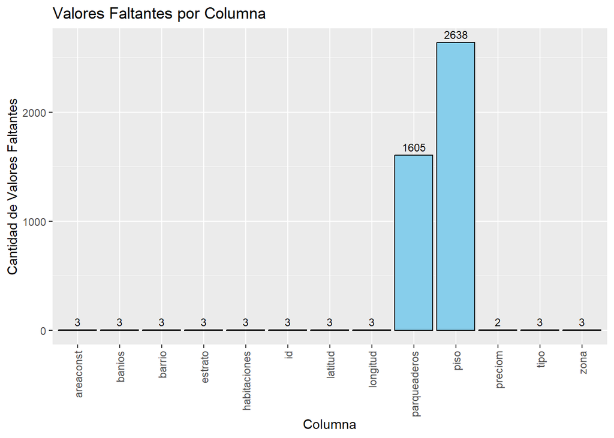

A continuación se grafican a mi criterio las principales visualizacones acerca del negocio inmobiliario presentado:

Para este primer gráfico se identifica que existen muchos registros en los rangos 167 - 234; 301 - 368 respecto al precio, por lo que para cuantificar dichos inmuebles es necesario en el preprocesamiento excluir los valores NA para tal operación;

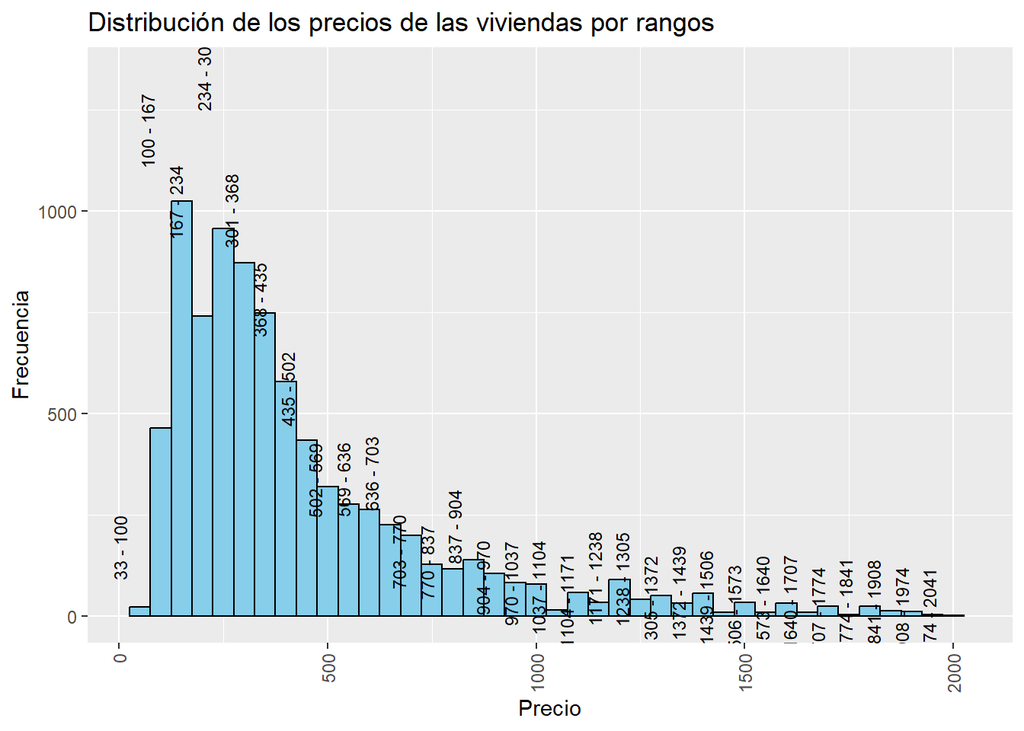

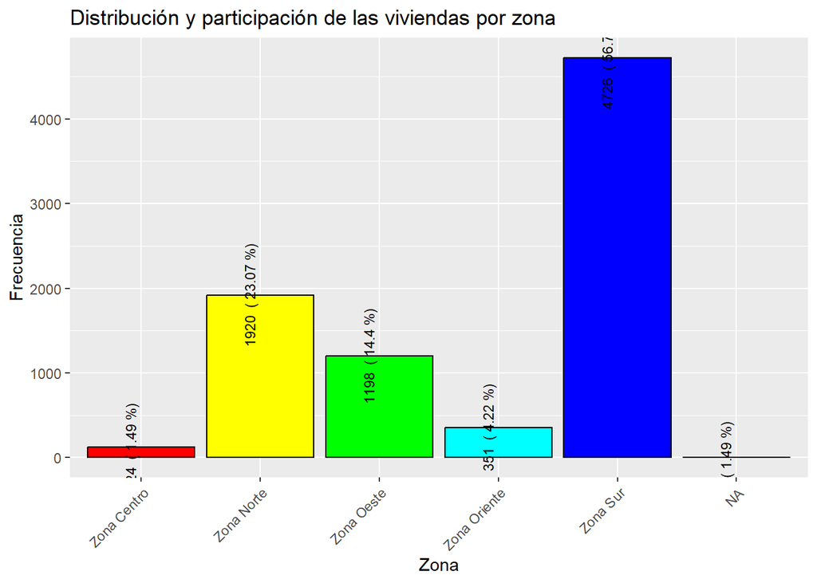

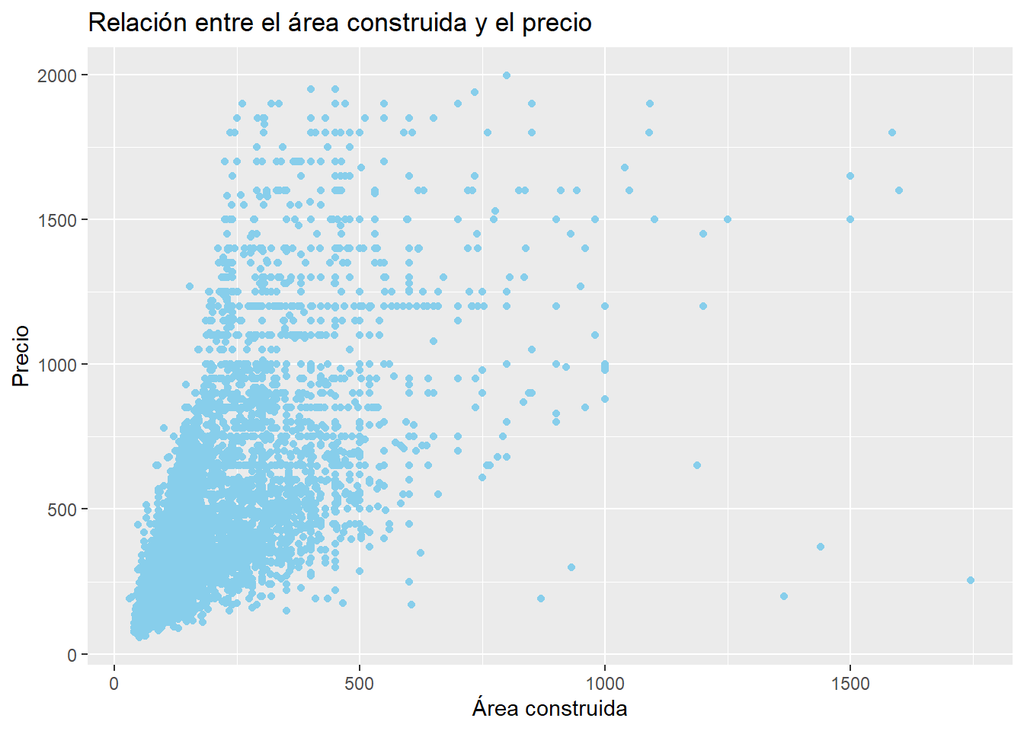

En este se determina que en general, las viviendas clasificadas en el estrato 6 tienen precios más altos en comparación con otras categorías de estratos. Mientras que las viviendas del estrato 5 tienen precios en un rango más bajo en comparación con el estrato 6, pero aún así, relativamente más altos que otros estratos inferiores.

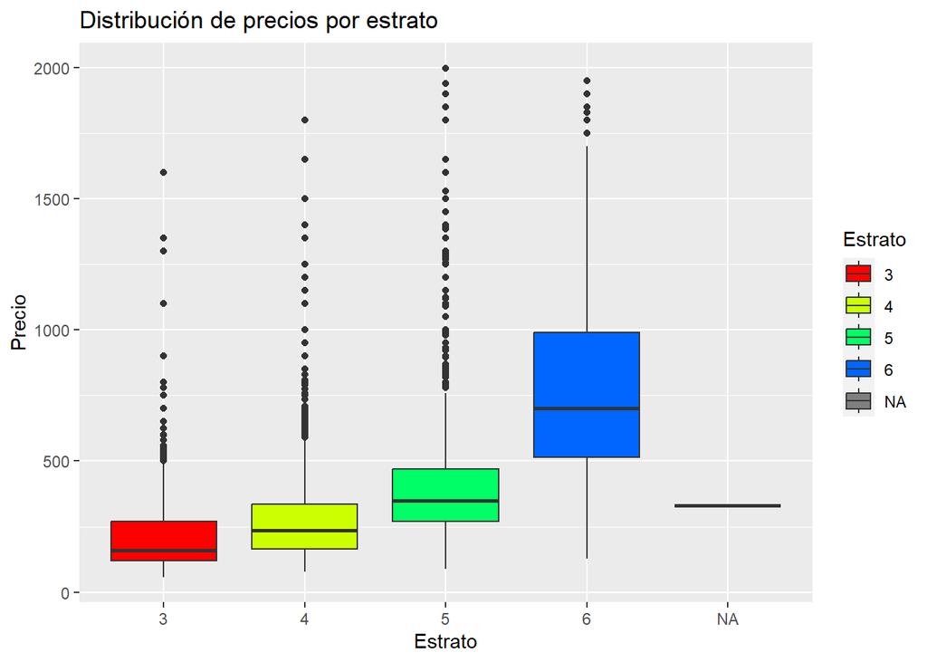

En los siguientes gráficos se presenta la distribución de tipo de vivienda, en este primero, se observa que si bien existen mas apartamentos que casas en el conjunto de datos, el segundo gráfico nos da cuenta que existe al menor por tipo de vivienda una mayor área construida en las casas.

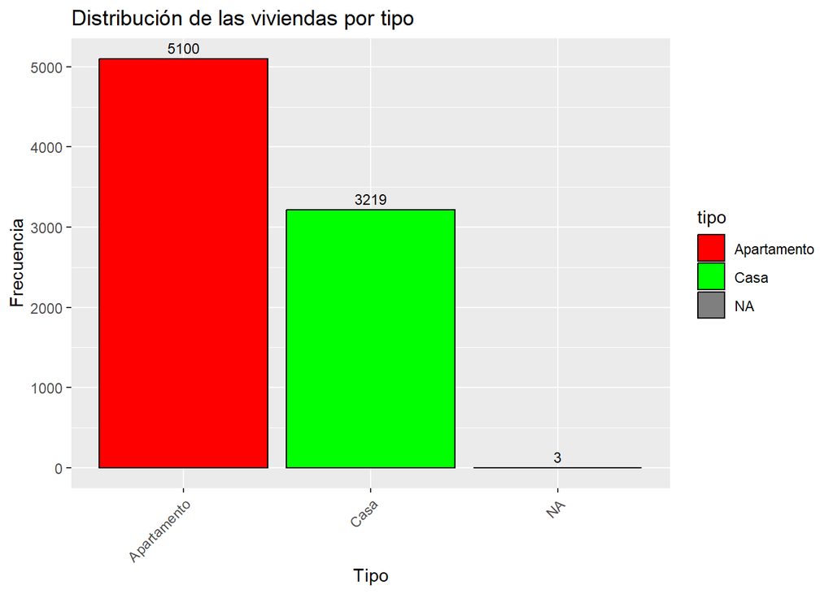

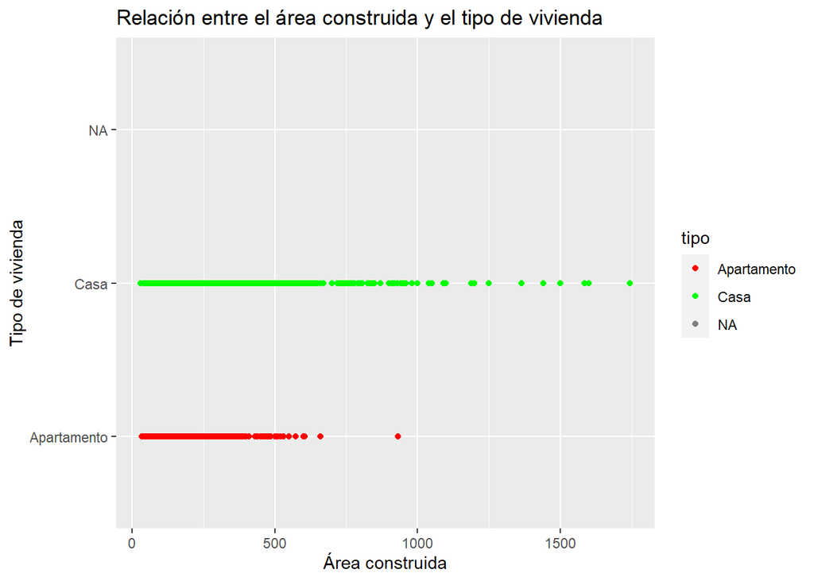

## Preprocesamiento de datos:

A partir de este momento con el conocimiento del conjunto de datos, se procede a la eliminación de la columna ID,longitud y latitud que a mi concepto no aportan valor al informe. De otra parte se da el tratamiento correspondiente a los valores ausentes o faltantes que en el análisis exploratorio de datos impidieron que se analizara la correlación por estar presentes.

```
##      zona               piso              estrato         preciom
##  Length:8322        Length:8322        Min.   :3.000   Min.   :  58.0
##  Class :character   Class :character   1st Qu.:4.000   1st Qu.: 220.0
##  Mode  :character   Mode  :character   Median :5.000   Median : 330.0
##                                        Mean   :4.634   Mean   : 433.9
##                                        3rd Qu.:5.000   3rd Qu.: 540.0
##                                        Max.   :6.000   Max.   :1999.0
##                                        NA's   :3       NA's   :2
##    areaconst       parqueaderos        banios        habitaciones
##  Min.   :  30.0   Min.   : 1.000   Min.   : 0.000   Min.   : 0.000
##  1st Qu.:  80.0   1st Qu.: 1.000   1st Qu.: 2.000   1st Qu.: 3.000
##  Median : 123.0   Median : 2.000   Median : 3.000   Median : 3.000
##  Mean   : 174.9   Mean   : 1.835   Mean   : 3.111   Mean   : 3.605
##  3rd Qu.: 229.0   3rd Qu.: 2.000   3rd Qu.: 4.000   3rd Qu.: 4.000
##  Max.   :1745.0   Max.   :10.000   Max.   :10.000   Max.   :10.000
##  NA's   :3        NA's   :1605     NA's   :3        NA's   :3
##      tipo              barrio
##  Length:8322        Length:8322
##  Class :character   Class :character
##  Mode  :character   Mode  :character
##
##
##
##
```

```
## tibble [4,808 × 10] (S3: tbl_df/tbl/data.frame)
##  $ zona        : chr [1:4808] "Zona Sur" "Zona Norte" "Zona Norte" "Zona Norte" ...
##  $ piso        : chr [1:4808] "02" "01" "01" "01" ...
##  $ estrato     : num [1:4808] 4 5 5 4 5 5 5 4 5 6 ...
##  $ preciom     : num [1:4808] 400 260 240 220 310 320 780 625 750 520 ...
##  $ areaconst   : num [1:4808] 280 90 87 52 137 150 380 355 237 98 ...
##  $ parqueaderos: num [1:4808] 3 1 1 2 2 2 2 3 2 2 ...
##  $ banios      : num [1:4808] 5 2 3 2 3 4 3 5 6 2 ...
##  $ habitaciones: num [1:4808] 3 3 3 3 4 6 3 5 6 2 ...
##  $ tipo        : chr [1:4808] "Casa" "Apartamento" "Apartamento" "Apartamento" ...
##  $ barrio      : chr [1:4808] "3 de julio" "acopi" "acopi" "acopi" ...
```

## 1. Análisis de Componentes Principales (PCA):

Para efectos de este analisis, se presentan a continuación los valores de desviación estándar indican la cantidad de variabilidad en los datos explicada por cada componente principal. Además para facilitar este paso se escogieron unicamente las variables numericas, en donde; la proporción de varianza y la proporción acumulativa de varianza indican la cantidad de variabilidad total en los datos explicada por cada componente principal y por las componentes principales anteriores, respectivamente. En este caso:

La primera componente principal (PC1) explica aproximadamente el 59.32% de la varianza total en los datos. Las dos primeras componentes principales (PC1 y PC2) explican aproximadamente el 79.06% de la varianza total en los datos. Las tres primeras componentes principales (PC1, PC2 y PC3) explican aproximadamente el 87.12% de la varianza total en los datos. Las cuatro primeras componentes principales (PC1, PC2, PC3 y PC4) explican aproximadamente el 92.83% de la varianza total en los datos. Las cinco primeras componentes principales (PC1, PC2, PC3, PC4 y PC5) explican aproximadamente el 96.94% de la varianza total en los datos. Todas las seis componentes principales explican el 100% de la varianza total en los datos, lo cual es esperado ya que estamos utilizando todas las variables en el análisis.

```
## Importance of components:
##                           PC1    PC2     PC3     PC4     PC5     PC6
## Standard deviation     1.8866 1.0884 0.69530 0.58528 0.49647 0.42886
## Proportion of Variance 0.5932 0.1974 0.08057 0.05709 0.04108 0.03065
## Cumulative Proportion  0.5932 0.7906 0.87117 0.92827 0.96935 1.00000
```

En este caso, el resumen del PCA muestra seis componentes, pero se observa que la mayoría de la varianza se explica con las dos primeras componentes principales (PC1 y PC2), que capturan el 79.06% de la varianza total. Esto sugiere que solo las dos primeros componentes principales se pueden considerar para simplificar el análisis, ya que representan la mayor parte de la variabilidad en los datos.

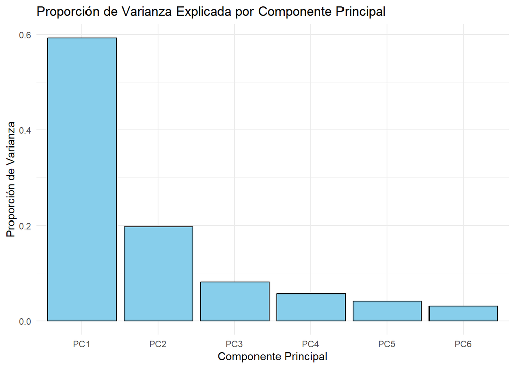

```
## `geom_line()`: Each group consists of only one observation.
## ℹ Do you need to adjust the group aesthetic?
```

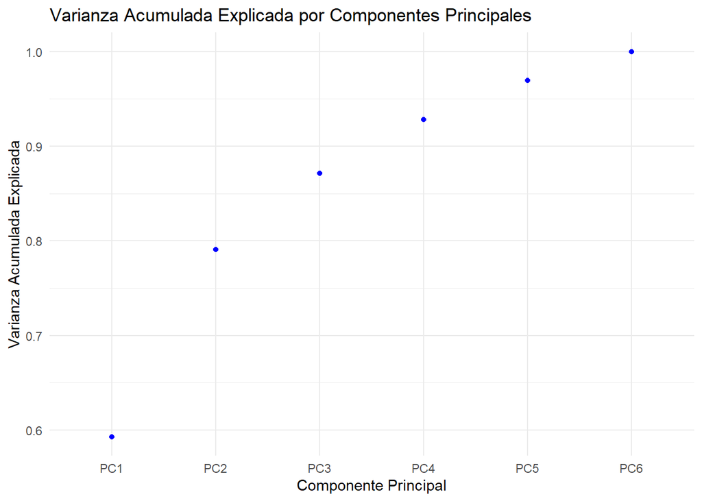

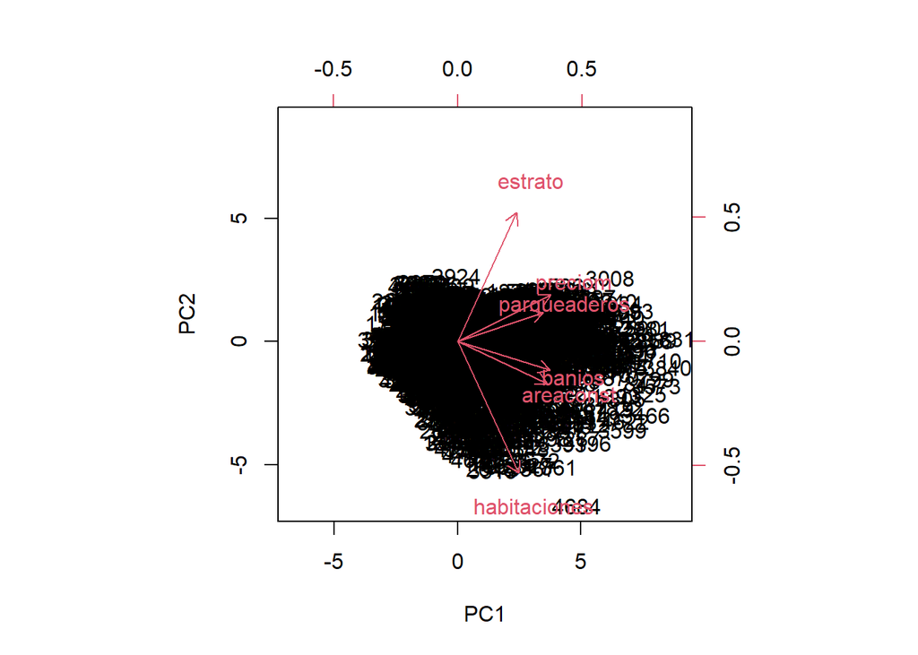

De acuerdo al material de la asignatura y lo observado en literatura se puede aplicar la “regla del codo” en el análisis de componentes principales, en esta se calculara la varianza explicada por cada componente principal y se trazaría un gráfico para identificar el punto en el que se produce un cambio significativo en la pendiente (el “codo”), en este se observa que la curva se genera para el primer y segun componente para confirmar lo observado anteriormente.

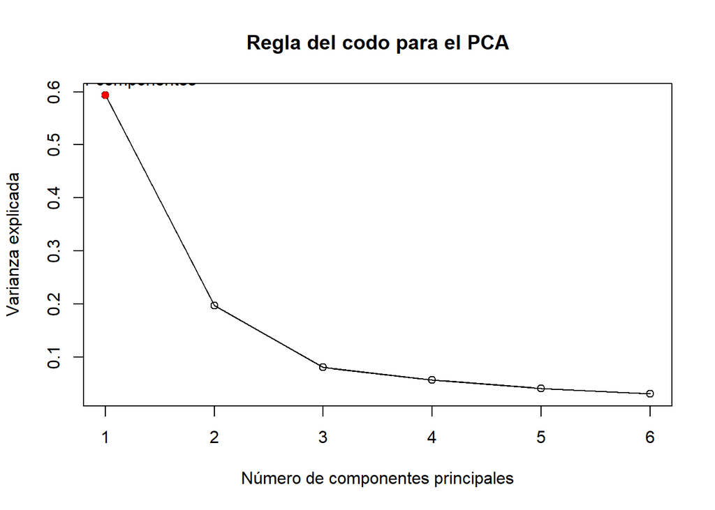

## 2. Análisis de Conglomerados (Clustering):

```
##      preciom  areaconst
## 1  2.4677661  2.1167169
## 2  0.4802026  0.5818992
## 3 -0.5434125 -0.5423895
```

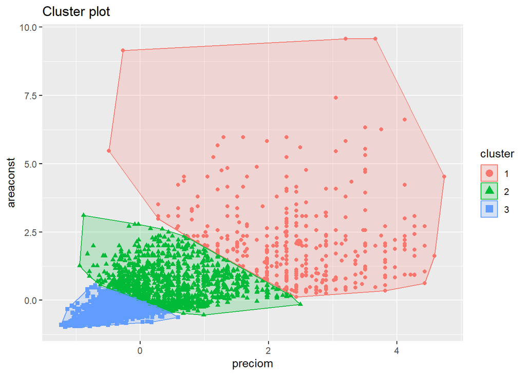

## 3.Análisis de Correspondencia:

El análisis de correspondencia múltiple (ACM) realizado revela información importante sobre las relaciones entre las variables categóricas en el conjunto de datos. Las dimensiones principales identificadas muestran la estructura subyacente en los datos y cuánto de la varianza total de los datos explican.

En primer lugar, las dimensiones principales capturan el grado de asociación entre las categorías de las variables. Por ejemplo, la Dimensión 1, con una varianza explicada del 0.711 y que representa el 0.770% de la varianza total, muestra una relación entre el tipo de propiedad (apartamento o casa) y la zona geográfica (centro, norte, oeste, oriente, sur), con valores de contraste significativos.

La Dimensión 3, con una varianza explicada del 0.658 y que representa el 0.713% de la varianza total, proporciona información adicional sobre la distribución espacial y las características particulares de ciertas zonas en relación con otras variables categóricas.

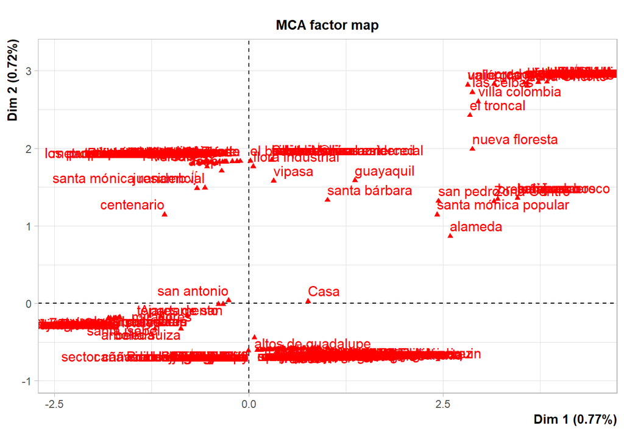

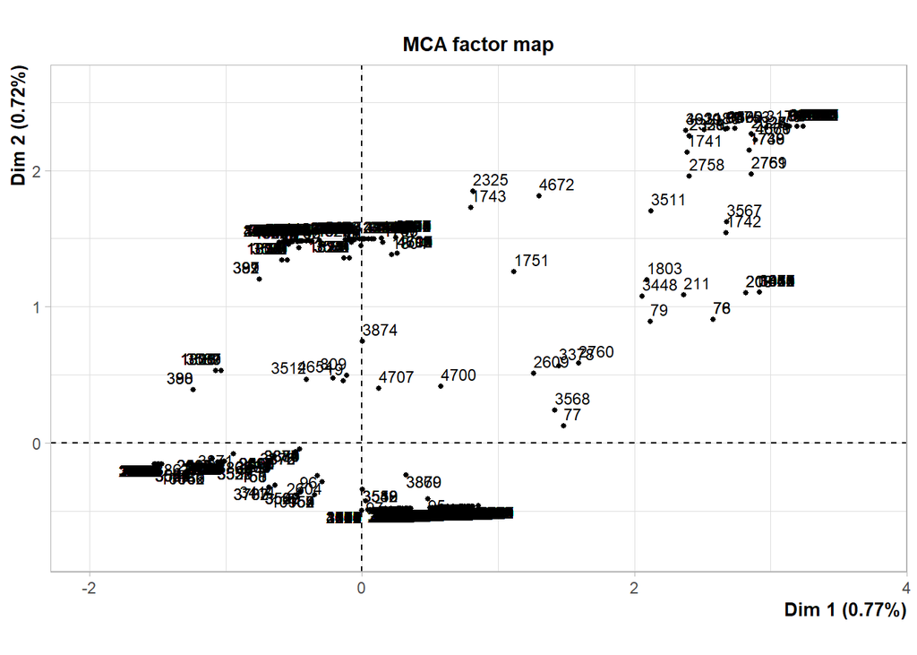

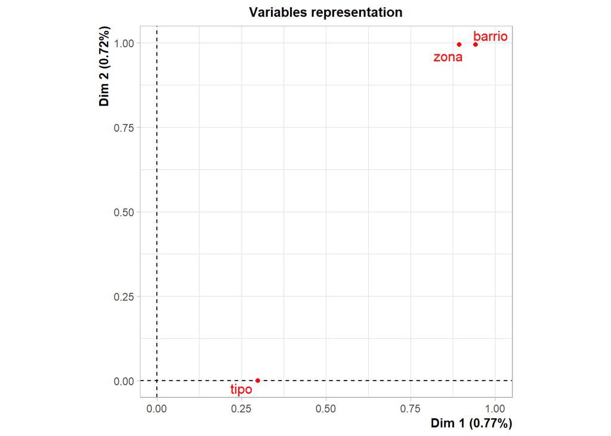

[output not shown]

[output cut: 165 more lines]

```
## Casa           1.230 |   0.003   0.000   0.000   0.172 |
## Zona Centro    7.938 |   1.385   0.727   0.014   8.340 |
## Zona Norte    59.470 |  -0.970   8.784   0.213 -31.973 |
## Zona Oeste    -5.281 |   1.470  17.137   0.401  43.921 |
## Zona Oriente  27.874 |   4.582  21.443   0.432  45.581 |
## Zona Sur     -53.359 |  -0.244   1.908   0.102 -22.167 |
## 3 de julio    -0.569 |  -0.247   0.001   0.000  -0.247 |
## acopi          7.843 |  -0.960   0.204   0.004  -4.408 |
## aguablanca    -0.607 |  -0.252   0.001   0.000  -0.252 |
##
## Categorical variables (eta2)
##                Dim.1 Dim.2 Dim.3
## tipo         | 0.298 0.000 0.000 |
## zona         | 0.894 0.995 0.987 |
## barrio       | 0.941 0.995 0.987 |
```

Conclusiones

Basadas en el análisis realizado, se extraen las siguientes conclusiones clave:

1. Existe una fuerte asociación entre el tamaño de la vivienda, la ubicación y el precio.
2. Se identificaron segmentos de mercado distintos a través del análisis de conglomerados, lo que sugiere la posibilidad de desarrollar estrategias de marketing personalizadas.
3. Las preferencias del mercado varían según la zona geográfica y el barrio, lo que resalta la importancia de adaptar la oferta de viviendas a las necesidades locales.